# Homework 4 — Stopping-distance predictions

STA5001 Bayesian & Computational Statistics

The starter code uses the BayesComp package from this checkout. To install it, run `R CMD INSTALL BayesComp` from the repository root.

**Concept.** A credible interval for the mean response and a prediction interval for an individual response include different sources of uncertainty. Predictions beyond the observed predictor range can also depend strongly on the assumed mean function.

**Example.** A synthetic bench experiment gives stopping distances in feet for runs at 10 to 30 mph. Write $z=(\text{speed}-20)/10$. Compare Gaussian regressions with mean $\beta_0+\beta_1z$ and with mean $\beta_0+\beta_1z+\beta_2z^2$, each with independent errors of variance $\sigma^2$. In each model use $\sigma^2\sim\operatorname{IG}(3,180)$ with shape 3 and scale 180, so $1/\sigma^2$ has Gamma shape 3 and rate 180. Use a conditional Normal coefficient prior with mean $(50,25)$ and covariance $\sigma^2\operatorname{diag}(4,4)$ for the linear fit. For the quadratic fit add an independent coefficient conditional on $\sigma^2$ with mean zero and variance $\sigma^2$.

**Starter code.** Inspect the observed runs on their original scales. Calculate the same centered predictor for both models. Use this definition again when constructing prediction rows for new speeds.

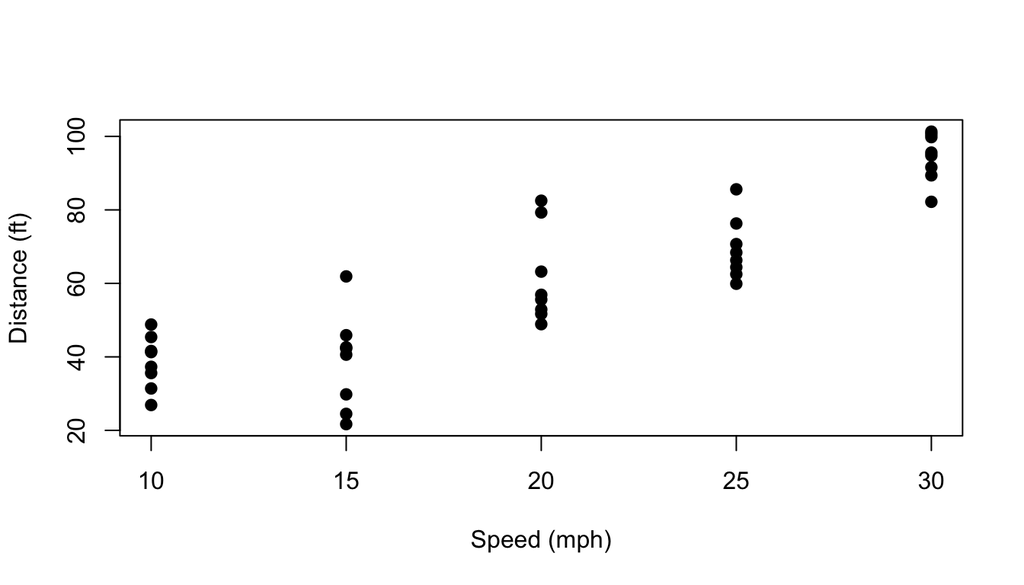

The synthetic bench runs at the five observed speeds.

```r
data("hw04_braking", package = "BayesComp")
braking_z <- (hw04_braking$speed_mph - 20) / 10
plot(distance_ft ~ speed_mph, data = hw04_braking, pch = 19,
     xlab = "Speed (mph)", ylab = "Distance (ft)")
```

## Tasks

1. **Fit both models.** Use the conjugate update from Section 4.2 and report the posterior coefficient means and the updated inverse-gamma parameters. Label the scale and shape of the variance posterior.
2. **Separate the two prediction targets.** At 20 mph and 38 mph, compute the posterior mean distance, a 95% equal-tailed credible interval for the mean response, and a 95% equal-tailed prediction interval for a future run. Use the Student distributions from Section 4.4.
3. **Interpret extrapolation.** Compare the two fits at the two speeds. Identify the part of the difference between the interval types that is due to residual variation and discuss the role of model form at 38 mph.

**Outputs and visuals.** Report the four model-by-speed predictions in one table. Make a panel for each model showing the data, posterior mean curve, and both pointwise interval types. Mark the observed speed range.

**Public-data reference.** The R dataset `cars` documents 50 observed stopping distances and their speeds. [R documentation for cars](https://stat.ethz.ch/R-manual/R-devel/library/datasets/html/cars.html)

R 4.6.0 · BayesComp 0.1.0